# ps_5

Arnav Srivastava

3/8/2020

## MadLibs

**1)** Not all respondents were asked every question. 2672 respondents were asked the question about whether the USA should create a gun registry.

**2)** Of the respondents that got asked all four gun policy questions, 23.73 percent are gun owners.

**3)** The average “agreement” score (from 1-4) on the statement_gun_rights variable is 2.05 for those respondents who live in households without guns, while the average “agreement” score in households with guns is 2.60.

**4)** Another set of questions asks about religion. The first ranked category of religion for the age group of people 18-30 is Nothing in particular. The first-ranked religion category for people 30 and older is Catholic.

**5)** Lots of people say that the younger generation has the highest percent of “nones;” people who answer “nothing in particular”, when you ask them their religion. In the 18-30 age group, “nothing in particular” is ranked 1, while in the 30 and above group, “nothing in particular” is ranked 4.

**6)** Consider again the nones (all people who responded “nothing in particular”) when asked about their religion. In this group, the most popular position is to Strongly Agree that it is more important for the government to control who owns guns than it is for the government to protect the right to own guns.

## Question 2: Simulations with List Columns

Card Colors

| Draw | First card red? | Second card red? | Color Outcome |
| --- | --- | --- | --- |
| diamonds, diamonds | TRUE | TRUE | Both red |
| spades, spades | FALSE | FALSE | Both black |
| diamonds, diamonds | TRUE | TRUE | Both red |
| hearts, clubs | TRUE | FALSE | Mixed |
| hearts, hearts | TRUE | TRUE | Both red |
| clubs, hearts | FALSE | TRUE | Mixed |
| diamonds, hearts | TRUE | TRUE | Both red |
| clubs, hearts | FALSE | TRUE | Mixed |
| hearts, diamonds | TRUE | TRUE | Both red |
| spades, hearts | FALSE | TRUE | Mixed |

After running 1000 simulations of drawing a pair of cards, the probability of drawing a red card and black card (a mixed pair), is 53.9 percent.

## Question 3: Modeling a Study Population

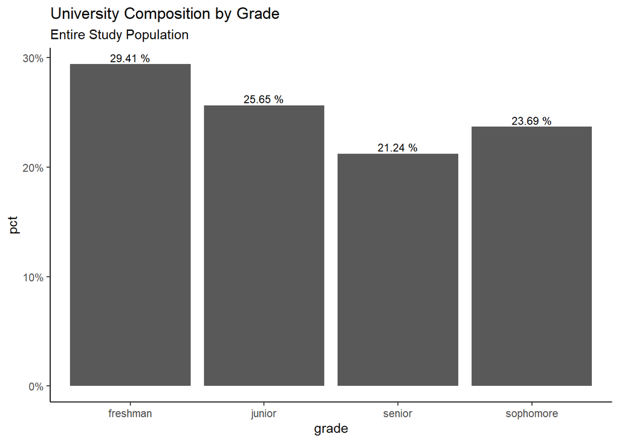

## Question 4: Sampling

[figure not shown]

## Question 5: Sampling and Sample Size

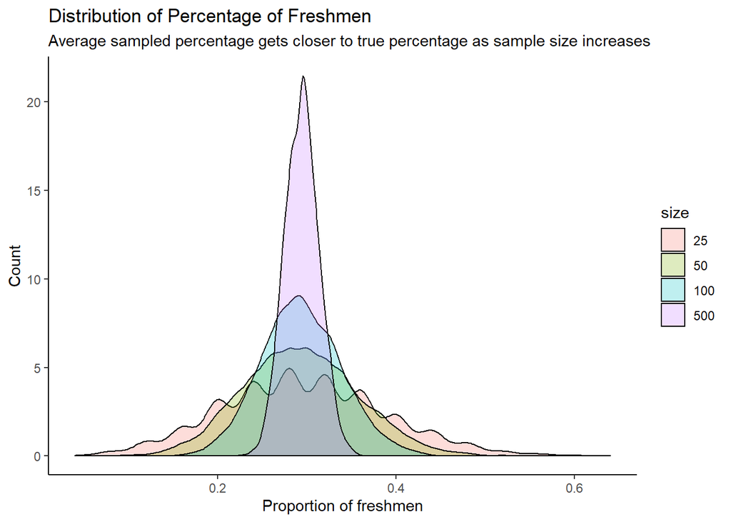

## Question 6: Publish Your Plot

Here is the Distribution of Percentage of Freshmen plot from the simulated Harvard College Class:

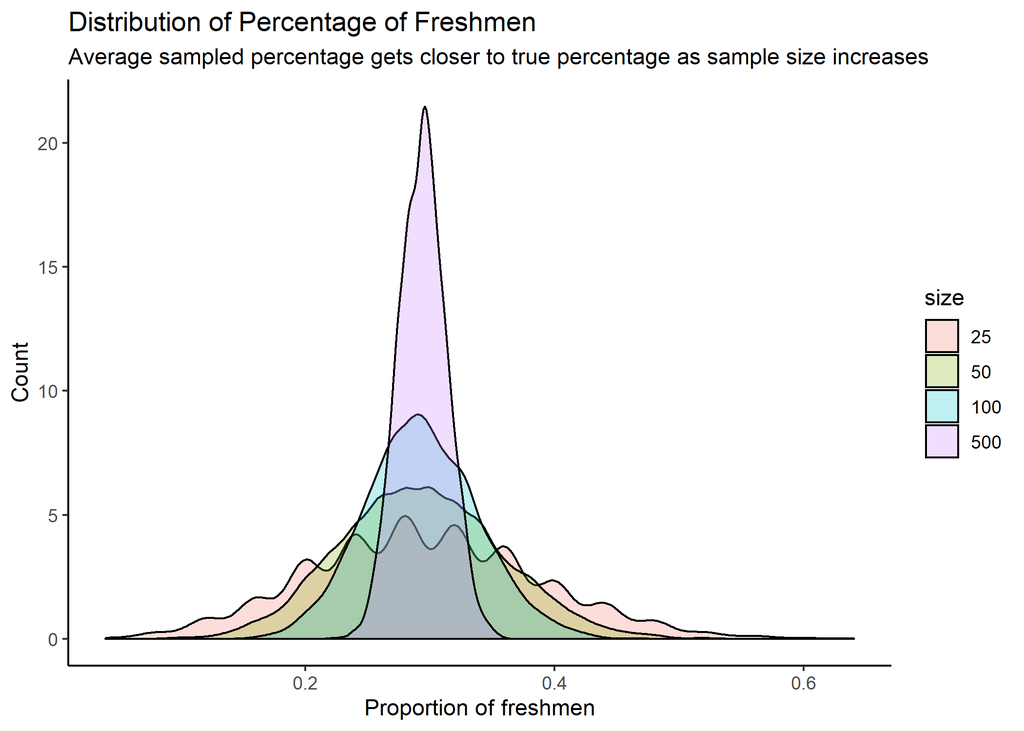

Here is the link to my RPubs account where the same graphic is uploaded: https://rpubs.com/arnavinator/584883

## Question 7: Reprex

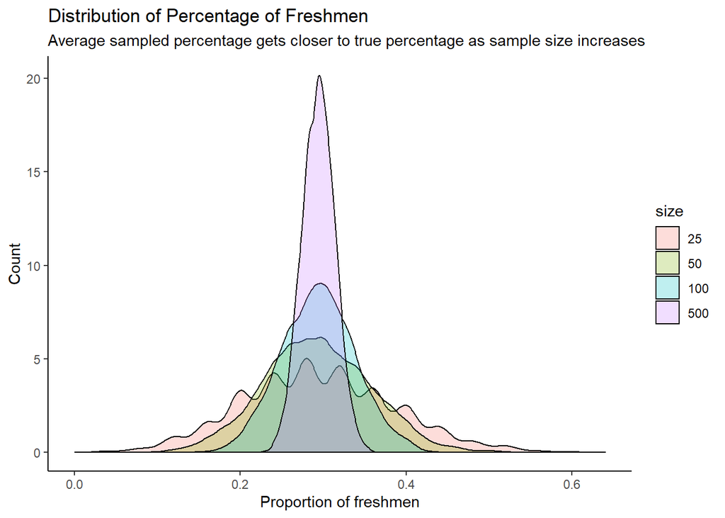

Collaborators: None. Check for titles!!!!